# Lab2

Damodar Pai

1/29/2024

# Tasks

## Task 1

```r
getwd()
```

```
## [1] "/Users/damodarpai/Documents/Labratories/Lab2"
```

Abovie is the working directorhy that we’ve saved our file.

## Task 2

```r
epagas = read.csv("EPAGAS.csv")
head(epagas)
```

```
##    MPG
## 1 36.3
## 2 41.0
## 3 36.9
## 4 37.1
## 5 44.9
## 6 36.8
```

Here we have read and printed the first 6 rows of the csv file.

## Task 3

```r
#myread=function(csv){
#  fl=paste("C:\\Users\\damodarpai\\Documents\\Labratories\\Lab2\\",csv,sep="")
#  read.table(fl,header=TRUE,sep=",")
#}
#myread(list.files())
mpg <- epagas$MPG
```

We assign the MPG column to the variable mpg.

```r
zval <- (mpg - mean(mpg))/(sd(mpg))
```

Above, we are trying to find the z-value for the mpg data. This is represented by our function and z-val.

```r
mean(zval)
```

```
## [1] 7.931156e-17
```

```r
(sd(zval)^2)
```

```
## [1] 1
```

We can further verify our results because the mean of our data is nearly 0 and our standard deviation is 1 which are both characteristics of the z-value.

```r
summary(zval)
```

```
##      Min.   1st Qu.    Median      Mean   3rd Qu.      Max.
## -2.892596 -0.545515  0.002481  0.000000  0.550478  3.269784
```

```r
zval[abs(zval) >= 2 & abs(zval)<= 3]
```

```
## [1] -2.892596  2.111752 -2.148148
```

```r
mpg[abs(zval) >= 2 & abs(zval)<= 3]
```

```
## [1] 30.0 42.1 31.8
```

Above we have a summary of the data as well as possible outliers that are defined as having outliers between 2 and 3.

```r
zval[(abs(zval)>3)]
```

```
## [1] 3.269784
```

```r
mpg[abs(zval)>3]
```

```
## [1] 44.9
```

Above, we have the defined outliers that are defined as having a z-value greater than 3.

```r
#IQR = 0.550478 + 0.545515
#zval[( (zval >= 0.550478 + (1.5*IQR) | zval<= -0.545515 - (1.5*IQR)) & abs(zval)<= 3)]
mycol = ifelse((abs(zval)>3) , "Blue",
        ifelse(( abs(zval) >= 2 & abs(zval)<= 3),"Red", "Black"))
```

The possible outliers are the ones with a z-value between 2 and 3. The defined outliers are the values with a z-value that is greater than 3. Above, we are setting the colors for the possible and defined outliers.

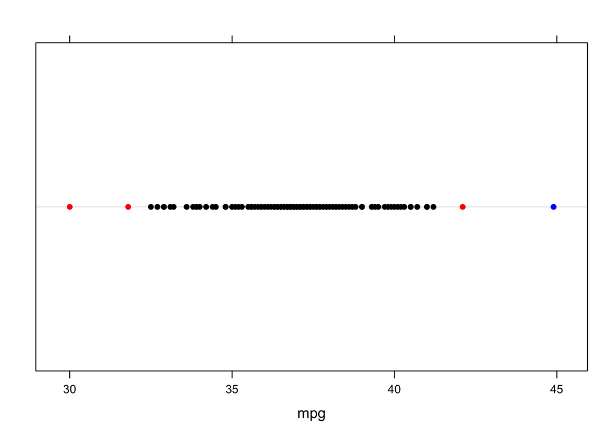

```r
library(lattice)
dotplot(mpg, col=mycol)
```

Above is a dotplot representative of the possible outliers represented in red and the defined outliers represented in blue.

## Task 4

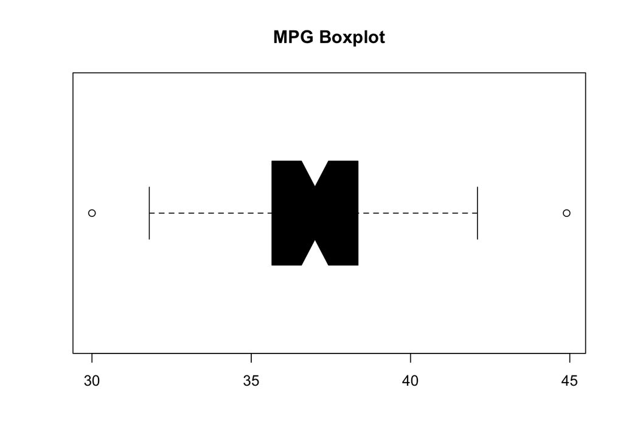

```r
boxplot(mpg,main = "MPG Boxplot", notch = TRUE,horizontal = TRUE, col="black")
```

```r
length(mpg[mean(mpg)-(2*sd(mpg)) < mpg & mpg < mean(mpg)+ (2*sd(mpg)) ])/length(mpg)
```

```
## [1] 0.96
```

Using Chebyshev’s rule, I predict that the proportion of data will be greater than 75%. Above is the proportion of our data that’s within an interval that is 2SD of the mean.

```r
length(mpg[mean(mpg)-(3*sd(mpg)) < mpg & mpg < mean(mpg)+ (3*sd(mpg)) ])/length(mpg)
```

```
## [1] 0.99
```

Above is the proportion of our data that’s within an interval that is 3SD of the mean.

Chesbyshev’s rule does agree with the data because the rule claims that for all data, atleast 75% of data is within 2SD and 89% of data is within 3 SD. Note any amount of data can be in 1SD. As we can see in the data above, 96% of data is within 2SD and 99% of data is within 3SD thus fulfilling the rule.

```r
length(mpg[mean(mpg)-(1*sd(mpg)) < mpg & mpg < mean(mpg)+ (1*sd(mpg)) ])/length(mpg)
```

```
## [1] 0.68
```

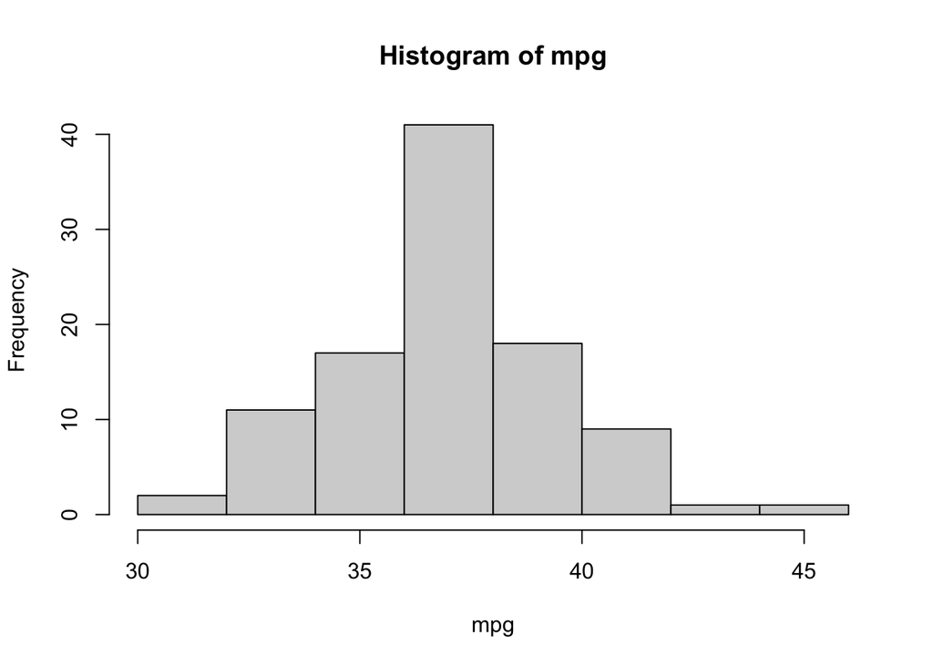

```r
hist(mpg)
```

Above is the proportion of our data that’s within an interval that is 1SD of the mean as well as a histogram to prove symmetry and a mound shape.

According to the Empirical Rule, as long as the data is in a mound shape, has a symmetric distribution,and around 68% of data is within 1SD and around 95% of data should be within 2SD and around 99% of data should be within 3SD.

This corresponds well with our data since 96% of our data is within 2SD and 99% of data is within 3SD.

The empirical rule is validated because I proved that atleast 68% of our data is within 1SD, atleast 95% is within 2SD and atleast 99% is within 3SD. Furthermore, I showed that the data is symmetric and has a mound shape.

[output not shown]